# Data Analyst Project P2:Investigate a Dataset

By Teresa Aysan

**Date** January 23, 2017

## Step One - Choose your dataset

I chose the Titanic Data. I downloaded it as csv file. I downloaded the description of the dataset from the Kaggle website - https://www.kaggle.com/c/titanic/data.

## Step Two - Get Organized

I have a single folder that contains my dataset (which I will not have to submit). My folder also contains my rough notes, a copy of the instructions and the rubric. I will use IPython notebook to submit both the code that I wrote and the report of my findings in the same document - this document.

## Step Three - Brainstorm Questions

- I was not interested in the basic questions such as the probability of surviving if you were higher class, female, child, old. I wanted to focus on something else, but I dont know the data very well, so I will just look at the data fields without looking at any values.
- I engaged 3 friends to brainstorm with me. I read to them the data fields that I had to work with and we came up with these question.
- what is the ratio of missing tickets by class? Is it logical to think that first class passengers would be more likely not to board the boat for various reasons, and hence survive, than third class passengers who have saved everything for a chance at a better life, and hence not likely to miss the boat and hence more likely not to survive.
- is there a relationship between the Port of Embarkation and the Class? And does that mean that family back home at certain points of embarkation were more likely to have survivors return home? (Embarked - Class - Survived)
- how many step children were there compared to total children? and what is the ratio of step children that survived compared to the ratio of total children that survived? We believe that there were fewer divorces back then, so fewer step children, but the interesting question is in whether or not step children were given as high a priority as natural children when attempting to get the children onto the boats.
- although there was great respect for the elderly, perhaps the elderly chose not to survive to give their place to the younger generation. Do the numbers support that hypothesis? and was there a class distinction in that selfless attitude?
- is there a relationship between the cabin number and survived? In other words, were people in the cabins that were closer to the bow more likely to have survived? I dont know if I will be able to tell from the cabin # if it was closer to the bow, but Kaggle may have a comment to that effect.

I have put the questions in order of my interest... I will start by answering the first one and so on down the list until I think I have done enough. I will probably not answer all of them.

## Step Three - Answer the Questions

### Step Three A - Ticket Number - Research the Questions

Here is the research done - in words:

Ticket numbers - after all of the research below (see references in the last cell), I realize that not much is known about the meaning of the ticket numbers. e.g. what does the prefix in the ticket number mean, does it indicate class or gender or port of embarkation and so on. The best idea that I read was the suggestion in link 27 (see references below) which suggested parsing the ticket number to see if there is a relationship between ticket number and survival. So I will try that. See last section of this report for the links. See reference section below, sub section called "Here are the links of research that I did on ticket number" for the reseach that I did into "Looking for ticket number".

## Step Three A - Ticket Number - Clearly Pose the Question

Passengers in which Classes and points of Embarkation were more likely to survive?

## Step Three A - Ticket Number - Answer the Question

In the code below, I am using NumPy and Pandas where they are appropriate to help me answer the questions.

Data fields required - that need to be wrangled / cleaned / parsed

- Ticket
- Survival
- Pclass
- Embarked

  I have chosen not to include name, age, sibsp, parch, cabin, fare, sex.

### Code for sorting / wrangling / cleaning / parsing the data

to run the code, you must "run all" cells

#### Import the libraries

```python
import pandas as pd
import numpy as np
import matplotlib.pyplot as plt
import seaborn as sns
from IPython.core.display import HTML
from itertools import groupby
from collections import OrderedDict
import operator
from numpy import array
%pylab inline
```

#### Load csv file - and include only the required fields to answer the question

*** If you are testing this code, enter your own path and filename ***

```python
path = 'c:/DA/CSV files/'
filename = 'titanic_data.csv'
path_filename = path + filename

#set to True to check filename
if False:
    print path_filename

#read the file
df = pd.read_csv(path_filename)

#set to true to check that the data is loaded ok by printing the first few rows
if True:
    print df.head()

#create a df of only the required fields - in the order that I want
df = df[['Ticket', 'Survived', 'Pclass', 'Embarked']]

#set to true to check that the data is loaded ok by printing the first few rows
if True:
    print df.head()

#check the datatype of the fields / columns
#set to true to check that the data is loaded ok by printing the first few rows
if False:
    print df.dtypes
```

```
   PassengerId  Survived  Pclass  \
0            1         0       3
1            2         1       1
2            3         1       3
3            4         1       1
4            5         0       3

                                                Name     Sex  Age  SibSp  \
0                            Braund, Mr. Owen Harris    male   22      1
1  Cumings, Mrs. John Bradley (Florence Briggs Th...  female   38      1
2                             Heikkinen, Miss. Laina  female   26      0
3       Futrelle, Mrs. Jacques Heath (Lily May Peel)  female   35      1
4                           Allen, Mr. William Henry    male   35      0

   Parch            Ticket     Fare Cabin Embarked
0      0         A/5 21171   7.2500   NaN        S
1      0          PC 17599  71.2833   C85        C
2      0  STON/O2. 3101282   7.9250   NaN        S
3      0            113803  53.1000  C123        S
4      0            373450   8.0500   NaN        S
             Ticket  Survived  Pclass Embarked
0         A/5 21171         0       3        S
1          PC 17599         1       1        C
2  STON/O2. 3101282         1       3        S
3            113803         1       1        S
4            373450         0       3        S
```

#### Code for cleaning the data - removing null values

```python
#find out which fields have null values
#set to true to check if there are null values in any of the fields
if False:
    print "Total number of rows"
    print len(df)
    print ""
    print "How many rows have null Ticket values"
    print len(df[pd.isnull(df.Ticket)])
    print ""
    print "How many rows have null Survived values"
    print len(df[pd.isnull(df.Survived)])
    print ""
    print "How many rows have null Pclass values"
    print len(df[pd.isnull(df.Pclass)])
    print ""
    print "How many rows have null Embarked values"
    print len(df[pd.isnull(df.Embarked)])

#since there are only 2 rows that have null values in any of the fields - they are only in the Embarked field -
#and since I cannot guess the port of embarkation,
#I will simply delete the 2 rows that have null embarked data.
df = df[df.Embarked>0]

#set to true to check if data is still good and if I have deleted the rows with null values
#and how many total rows there are in the df now
if False:
    print df.head()
    print ""
    print "How many rows have null Embarked values"
    print len(df[pd.isnull(df.Embarked)])
    print ""
    print "Total number of rows"
    print len(df)

#it worked. The null rows are removed and the data is now 2 rows less (891 - 2 = 889)
```

#### Code for parsing / splitting the ticket number - separating the leading prefix characters from the trailing numbers

```python
#first I want to clean the Ticket values so that the characters at the beginning of the ticket number
#do not have any spaces until it gets to the number at the end
#or I want to remove all the numbers at the end and put them in a new column

#create a df of just Ticket - probably not necessary, but easier for me to handle
ticket_df = df[['Ticket']]

#set to true to check that I now have a df with the ticket column. Print a few rows.
if False:
    print ""
    print "Check that I now have a df with the ticket column. Print a few rows."
    print ticket_df.head()
    print ""
#it worked

#split the column by parsing it based on the first space from the left hand side
#this did not produce the expected result because in some cases there are 2 spaces before getting to the numbers
#did NOT work
#set to true to check
if False:
    print "Split the column by parsing it based on the first space from the left hand side."
    print "This did not produce the expected result because in some cases there are 2 spaces before getting to the numbers."
    ticket_split_df = df['Ticket'].apply(lambda x: pd.Series(x.split(' ')))
    print ticket_split_df.head()
    print ""

#using this code, I get same result with data not properly lined up because the code starts from the left
#and in some cases there are 2 spaces before getting to the numbers
#did NOT work
#set to true to check
if False:
    foo = lambda x: pd.Series([i for i in (x.split(' '))])
    ticket_split_df = ticket_df['Ticket'].apply(foo)
    print "Try a different way: I get same result with data not properly lined up because the code starts from the left"
    print "and in some cases there are 2 spaces before getting to the numbers."
    print ticket_split_df.head()
    print ""


#split the column by parsing it based on the first space starting from the right hand side
#add the word reversed
#this works - this is good
#add column names
#convert the NaN to Empty
#combine the two right hand columns - but first convert them to strings
#this will also correct the STON/O2. data that sometimes shows as "STON/O 2." - note the space

foo = lambda x: pd.Series([i for i in reversed(x.split(' '))])
ticket_split_reverse_df = ticket_df['Ticket'].apply(foo)
ticket_split_reverse_df.columns = ['Ticket_No', 'Ticket_Prefix', 'Ticket_Prefix_2']
ticket_split_reverse_df = ticket_split_reverse_df.fillna('')
ticket_split_reverse_df['Ticket_Prefix'] = ticket_split_reverse_df[['Ticket_Prefix', 'Ticket_Prefix_2']]\
    .apply(lambda x: ''.join(str(value) for value in x), axis=1)
ticket_split_reverse_df = ticket_split_reverse_df[['Ticket_No', 'Ticket_Prefix']]

#set to True to confirm that the above worked by printing
if False:
    print "Split the column by parsing it based on the first space starting from the right hand side."
    print "Other clean up and combine the two right hand columns."
    print "Print a few rows to see that it worked. It worked."
    print ticket_split_reverse_df.head()
    print ticket_split_reverse_df.dtypes
    print df.head()
    print ""
    print "To check that len of sub dataset is same as dataset before combining them."
    print len(ticket_split_reverse_df)
    print len(df)
    print "End of vetted code"
    print ""

#combine the parsed data with the df data - axis =1 to combine the columns
final_ticket_df = pd.concat([ticket_split_reverse_df, df], axis=1)
final_ticket_df = final_ticket_df[['Ticket_Prefix', 'Ticket_No', 'Survived', 'Pclass', 'Embarked']]

#set to True to confirm by printing
if False:
    print "Combine the parsed data with the df data."
    print final_ticket_df.head()
    print len(final_ticket_df)
    print ""
```

#### Code for cleaning the data - removing special characters, standardizing as appropriate and converting all to uppercase

```python
#CLEAN THE TICKET_PREFIX
#remove special characters, standardize string as appropriate and convert all characters to uppercase

#set to true to print the data to see how it looks before cleaning
if False:
    print ""
    print "List the dataset before removing special characters"
    print final_ticket_df #have to print the whole thing to get a good picture
    print ""
#I see by looking at the data that the special characters are not required in Ticket_Prefix
#It would be better to remove them as it would make less groups.
#remove all spaces and convert all characters to upper case to make less groups later in the code
#back in the day, it did not matter so much if there was an extra dot or slash, people understood the meaning
#but in today's digital world, all spaces and characters matter, so they have to be cleaned

#replace special characters and blanks - use replace instead of strip,
#because strip only strips the first and last in the string:
final_ticket_df['Ticket_Prefix'] = final_ticket_df['Ticket_Prefix'].str.replace('.', '').str.replace('/', '').str.replace(' ', '').str.replace('STON', 'SOTON')
#make all characters upper case
final_ticket_df['Ticket_Prefix'] = map(lambda x: x.upper(), final_ticket_df['Ticket_Prefix'])
#replace 2SOTONO with SOTONO2 to make fewer groups because it is probably the same group
final_ticket_df['Ticket_Prefix'] = final_ticket_df['Ticket_Prefix'].str.replace('2SOTONO', 'SOTONO2')

#set to true to print the data to see how it looks after cleaning
if False:
    print "List the dataset AFTER removing special characters, blanks and setting all to UPPER"
    print final_ticket_df
    print ""
```

#### Code for adding the latitude and longitude of the ports of embarkation

I want to add latitude and longitude so that I can do bubbleplots by port of embarkation. I looked up the latitude and longitude on Google.

1. The Latitude and longitude of Cherbourg port France is 48.5335 / 7.7829.
2. The latitude and longitude of Queenstown, Blackpool, Blackpool, Blackpool FY3, UK is 53° 49' N / 3° 1' W = decimal 53.816667 / 3.016667
3. The latitude and longitude of Southampton, Southampton, UK is 50° 54' N / 1° 24' W = decimal 50.9 / 1.4

```python
#clean embarked - make all characters upper case
final_ticket_df['Embarked'] = map(lambda x: x.upper(), final_ticket_df['Embarked'])

#Change to True to check that they are all uppercase
if False:
    sorted_df_by_Embarked = final_ticket_df.sort_values(by=['Embarked'])
    print ""
    print "This counts the total records for each value of Embarked."
    print "It's OK that it is the same number in all fields. That meets the objective of checking that there are only 3 values for Embarked Ports (C, Q and S)."
    print ""
    print sorted_df_by_Embarked.groupby('Embarked').count()
    print ""
    #I can see that there are only 3 values, therefore the Embarked data is clean

#change to True to test boolean answer
if False:
    print "Test boolean answer."
    print final_ticket_df['Embarked'] == 'C'
    print ""

#add the 2 new columns
final_ticket_df['Latitude'] = 0.000000
final_ticket_df['Longitude'] = 0.000000


#change the values of latitude and longitude
#based on the port of embarkation
final_ticket_df.loc[final_ticket_df.Embarked == 'C', ['Latitude', 'Longitude']] = 48.5335, 7.7829
final_ticket_df.loc[final_ticket_df.Embarked == 'Q', ['Latitude', 'Longitude']] = 53.816667, 3.016667
final_ticket_df.loc[final_ticket_df.Embarked == 'S', ['Latitude', 'Longitude']] = 50.9, 1.4

#set to True to check that latitude and longitude are added.
if False:
    print "Check that latitude and longitude are added."
    print final_ticket_df.head()
    print final_ticket_df
    print ""
#it prints well. The latitude and longitude are added
```

NOTES were added to the sections as the project progressed through:

A. Dataframe data analysis

B. Scatter / Bubble Charts

C. Quantities Charts

D. Percentage Charts

E. Summary

A. NOTES on the numbers from the dataframes:

A1. The numbers by Port of Embarkation and by Class by Port of Embarkation:

```
The numbers show that Cherbourg had a greater percent of survivors and that Southampton had the least.
There are many more passengers from Southampton than from the other ports.
The quantities of passengers and survivors are plotted on the scatter / bubble charts in the next section.
A visual can be more effective in communicating results.

There is a huge difference between the classes, which was expected from general knowledge that passengers
in Class 3 did not survive as much as passengers in Class 1.
```

A2. Why does Cherbourg have the highest percentage of survivors to passengers (55%)? Was there a higher percentage of first class passengers in Cherbourg than there was in other ports? This question is investigated below in the percentage section.

A3. Some of the numbers in Queenstown skew the results:

```
The total number of Passengers in Queenstown in Class1 (referred to as 1Q) is only 2, and in Class2
(referred to as 2Q) is only 3. These quantities are very low.
There is 1 survivor from 1Q and 2 survivors from 2Q.

These low quantities will skew the percentage of survivors to passengers for 1Q and 2Q.
We see this on the percentage charts and we may have to eliminate 1Q and 2Q results
when drawing conclusions on the ratio of survivors by Class by Port of Embarkation.
```

A4. Investigation that led nowhere: Were the Southhampton cabins from certain ports in a less desirable part of the ship? I had hoped that the ticket_no would be an indication of an answer to this question, but even though I cleaned the ticket_no data, it was not clear what the ticket numbers meant. I searched online to see if any research had been done in the archives on what the ticket numbers or prefix meant, but I was unable to find any answers. This was disappointing.

A5. Other factors outside of the scope of this project: This project is centered on Passengers and Survivors by Class by Port. But a comprehensive conclusion would also consider the number of females, children, elderly and so on between the ports. These factors are outside of the scope of this project, but the data exists to analyse it in another project.

#### Code for scatter / bubble plot of latitude and longitude

Total Passengers by port of embarkation

```
Number of passengers by port of embarkation based on latitude and longitude.
    Latitude  Longitude  Survived
0  48.533500   7.782900       168
1  50.900000   1.400000       644
2  53.816667   3.016667        77
```

```
WARNING: pylab import has clobbered these variables: ['colors']
`%matplotlib` prevents importing * from pylab and numpy
```

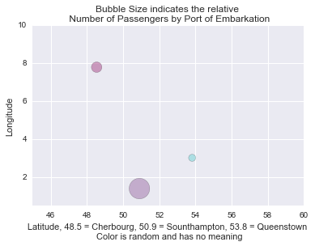

```python
%pylab inline

# A scatter / bubble plot of passengers by point of embarkation with latitude and longitude as the x and y axes
# and passengers as the bubble size
lat_lon_group = final_ticket_df.groupby(['Latitude', 'Longitude'], as_index=False)

passengers = lat_lon_group['Survived'].count() #this is not total passengers, it is number of passengers by port
#even though I use the field 'survived', because I use 'count' and not 'sum', it is the number of passengers
#because it counts the rows that have either 0 or 1 for 'survived'
#I will use sum to count the number of survivors in the 2nd graph below

print ""
print "Number of passengers by port of embarkation based on latitude and longitude."
print passengers
print ""

#create the bubble plot of passengers by port of embarkation based on latitude and longitude
N = len(passengers)
colors = np.random.rand(N,3)
plt.scatter(passengers['Latitude'], passengers['Longitude'], s=passengers['Survived'], c=colors, alpha=0.5)

plt.xlim(xmin=45, xmax=60)
plt.ylim(ymin=.5, ymax=10)
plt.xlabel('Latitude, 48.5 = Cherbourg, 50.9 = Sounthampton, 53.8 = Queenstown \n Color is random and has no meaning' )
plt.ylabel('Longitude')
plt.title('Bubble Size indicates the relative \n Number of Passengers by Port of Embarkation')
```

#### Code for scatter / bubble plot of latitude and longitude

Total Survivors by port of embarkation

```
Number of survivors by port of embarkation based on latitude and longitude.
    Latitude  Longitude  Survived
0  48.533500   7.782900        93
1  50.900000   1.400000       217
2  53.816667   3.016667        30
```

```
WARNING: pylab import has clobbered these variables: ['colors']
`%matplotlib` prevents importing * from pylab and numpy
```

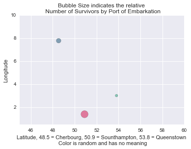

```python
%pylab inline

# A  scatter / bubble plot of survivors by point of embarkation with latitude and longitude as the x and y axes
# and survivors as the bubble size
lat_lon_group = final_ticket_df.groupby(['Latitude', 'Longitude'], as_index=False)

survivors = lat_lon_group['Survived'].sum() #I use sum to add up the number of survivors
print ""
print "Number of survivors by port of embarkation based on latitude and longitude."
print survivors
print ""

#create the scatter / bubble plot of survivors
N = len(survivors)
colors = np.random.rand(N,3)
plt.scatter(survivors['Latitude'], survivors['Longitude'], s=survivors['Survived'], c=colors, alpha=0.5)

plt.xlim(xmin=45, xmax=60)
plt.ylim(ymin=.5, ymax=10)
plt.xlabel('Latitude, 48.5 = Cherbourg, 50.9 = Sounthampton, 53.8 = Queenstown \n Color is random and has no meaning')
plt.ylabel('Longitude')
plt.title('Bubble Size indicates the relative \n Number of Survivors by Port of Embarkation')
```

#### Code for scatter / bubble plot of latitude and longitude - combining passengers and survivors onto one plot

Total Passengers and Survivors by port of embarkation Adding annotations and multiple line labels

```
Number of passengers by port of embarkation based on latitude and longitude.
    Latitude  Longitude  Survived
0  48.533500   7.782900       168
1  50.900000   1.400000       644
2  53.816667   3.016667        77


Number of survivors by port of embarkation based on latitude and longitude.
    Latitude  Longitude  Survived
0  48.533500   7.782900        93
1  50.900000   1.400000       217
2  53.816667   3.016667        30
```

```
WARNING: pylab import has clobbered these variables: ['colors']
`%matplotlib` prevents importing * from pylab and numpy
```

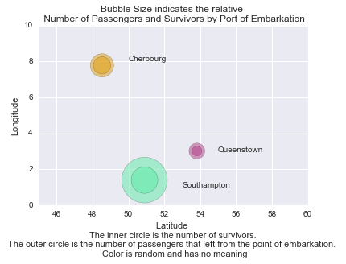

```python
%pylab inline

# A scatter / bubble plot of passengers and survivors by point of embarkation with latitude and longitude as the x and y axes
# and passengers and survivors as the bubble size

#I increased s= by 5 to make the bubbles bigger.
#I used \n to put multiple lines in the x label
#I added annotations for the Bubbles so that the port names are beside the appropriate bubbles

lat_lon_group = final_ticket_df.groupby(['Latitude', 'Longitude'], as_index=False)

passengers = lat_lon_group['Survived'].count()
print ""
print "Number of passengers by port of embarkation based on latitude and longitude."
print passengers
print ""

survivors = lat_lon_group['Survived'].sum()
print ""
print "Number of survivors by port of embarkation based on latitude and longitude."
print survivors
print ""

#Create the dual bubble plot
N = len(passengers)
colors = np.random.rand(N,3)
plt.scatter(passengers['Latitude'], passengers['Longitude'], s=passengers['Survived']*5, c=colors, alpha=0.5)

plt.scatter(survivors['Latitude'], survivors['Longitude'], s=survivors['Survived']*5, c=colors, alpha=0.5)

plt.xlim(xmin=45, xmax=60)
plt.ylim(ymin=0, ymax=10)
plt.annotate('Cherbourg', xy=(50,8))
plt.annotate('Southampton', xy=(53,1))
plt.annotate('Queenstown', xy=(55,3))
plt.xlabel('Latitude \n The inner circle is the number of survivors. \n The outer circle is the number of passengers that left from the point of embarkation.  \n Color is random and has no meaning')
plt.ylabel('Longitude')
plt.title('Bubble Size indicates the relative \n Number of Passengers and Survivors by Port of Embarkation')

#the above worked well.
```

B. NOTES on the Scatter / Bubble Graphs

B1: The Bubble Graphs confirm what we suspected from looking at the dataframe data: that there were more survivors as percent from Cherbourg and that Southampton had the least. We can tell this by looking at how close the inner circle (survivors) comes to the outer circle (passengers). This will be investigated by class in the QUANTITIES and PERCENTAGE sections below.

#### Code for sorting and grouping and counting passengers and survivors by Port of Embarkation and also by Classes by Port of Embarkation

```python
#going into this project, after the brainstorming, I thought I would be able to get more information from the ticket
#number than I was able to get
#so, for the rest of the analysis, I will use class, port of embarkation, number of passengers and number of survivors
#to do my analysis

#ANALYSIS BY Port of Embarkation:
#sort by Embarked:
sorted_df_by_Embarked = final_ticket_df.sort_values(by=['Embarked'])

#now I want to count the passengers and sum the survivors so that I can do comparisons by port of embarkation
#I can use the 'Survived' field for both count which will give # of passengers and sum which will give # of survivors
f = { 'Survived':['count' , 'sum']} #to simplify the code in the next statement. I could also substitute the right hand side for "f" and it works fine

Embarked_summary_df = sorted_df_by_Embarked.groupby(["Embarked"]).agg(f).reset_index() #reset the index when adding the columns

# This will create a multi-index header row, so rename the columns:
Embarked_summary_df.columns = ["Embarked", "Passengers","Survived"]
Embarked_summary_df["%StoP"] = ((Embarked_summary_df["Survived"] / Embarked_summary_df["Passengers"])*100)

#ANALYSIS BY Pclass by Port of Embarkation:
sorted_df_by_Pclass_by_Embarked = final_ticket_df.sort_values(by=['Pclass','Embarked'])

Pclass_Embarked_summary_df = sorted_df_by_Pclass_by_Embarked.groupby(["Pclass","Embarked"]).agg(f).reset_index() #reset the index when adding the columns
Pclass_Embarked_summary_df.columns = ["Pclass","Embarked", "Passengers","Survived"]
Pclass_Embarked_summary_df["%StoP"] = ((Pclass_Embarked_summary_df["Survived"] / Pclass_Embarked_summary_df["Passengers"])*100)


#these dfs will be used in the charts in the next section
```

```python
print "DATABASE DISPLAY"
print ""
print "Output of the database data, for easier identification of the fine differences between "
print "the Classes, Ports, Passengers and Survivors:"
print ""
print ""
print ""
print ""
print "Embarked_summary_df: This displays the total number of Passengers and Survivors for each Port of Embarkation."
print ""
print "C = Cherbourg, Q = Queenston, S = Southampton."
print ""
print "It also displays the percent of survived to passengers for each port."
print ""
print Embarked_summary_df
print ""
print ""
print ""
print ""
print "Pclass_Embarked_summary_df: This displays the total number of Passengers and Survivors by Class by Port of Embarkation."
print ""
print "It also displays the percent of survived to passengers for each class by port."
print ""
print Pclass_Embarked_summary_df
print ""
```

```
DATABASE DISPLAY

Output of the database data, for easier identification of the fine differences between
the Classes, Ports, Passengers and Survivors:




Embarked_summary_df: This displays the total number of Passengers and Survivors for each Port of Embarkation.

C = Cherbourg, Q = Queenston, S = Southampton.

It also displays the percent of survived to passengers for each port.

  Embarked  Passengers  Survived      %StoP
0        C         168        93  55.357143
1        Q          77        30  38.961039
2        S         644       217  33.695652




Pclass_Embarked_summary_df: This displays the total number of Passengers and Survivors by Class by Port of Embarkation.

It also displays the percent of survived to passengers for each class by port.

   Pclass Embarked  Passengers  Survived      %StoP
0       1        C          85        59  69.411765
1       1        Q           2         1  50.000000
2       1        S         127        74  58.267717
3       2        C          17         9  52.941176
4       2        Q           3         2  66.666667
5       2        S         164        76  46.341463
6       3        C          66        25  37.878788
7       3        Q          72        27  37.500000
8       3        S         353        67  18.980170
```

#### QUANTITIES BAR CHARTS: Plot the dataframe data in bar charts with multiple keys. First: total quantity of Passengers and Survivors by Port of Embarkation. Then: quantity of Passengers and Survivors by Class by Port of Embarkation. Use an overlay of survivors on top of passengers.

```
WARNING: pylab import has clobbered these variables: ['f', 'colors']
`%matplotlib` prevents importing * from pylab and numpy
```

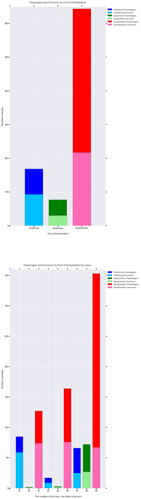

```python
%pylab inline

#setup the output for multiple charts in the output
#add figsize to increase the height of the y axis
multiple_bars = plt.figure(1, figsize=(8,40))


# QUANTITIES - FIRST CHART: create a bar chart showing total passengers and survivors overlay
# by port of Embarkation
# use the data above

#create bar charts of Passengers and Survivors by Port of Embarkation
# in naming, C = Cherbourg, Q = Queenston and S = Southampton; 1=Class1, 2=Class2, 3=Class3

def BarChartPandSbyP():
    #CHANGE THE FIRST NUMBER TO THE NUMBER OF GRAPHS THAT I WANT
    #graph the bar chart as the first figure on row 1 of charts in the figure
    az = plt.subplot(211)

    #passengers by Port
    #simplify the naming for shorter code for the charts.
    # y is Port C, z is Port Q, k is Port S
    # iloc[,1] is number of passengers
    y = [Embarked_summary_df.iloc[0,1]]
    z = [Embarked_summary_df.iloc[1,1]]
    k = [Embarked_summary_df.iloc[2,1]]

    #create an x array that will be used to position the bars in the right place on the figure
    x = array( [1])

    #give the bars names for shorter coding; position per the x array, widths of the bars,
    #         color and alignment
    bar1 = az.bar(x, y,width=0.75,color='b',align='center')
    bar3 = az.bar(x+1, z,width=0.75,color='g',align='center')
    bar5 = az.bar(x+2, k,width=0.75,color='r',align='center')

    #survivors overlay
    #simplify the naming for shorter code for the charts
    # iloc[,2] is number of survivors
    y = [Embarked_summary_df.iloc[0,2]]
    z = [Embarked_summary_df.iloc[1,2]]
    k = [Embarked_summary_df.iloc[2,2]]

    #create an x array that will be used to position the bars in the right place on the figure
    #to match up the survivor overlay with the passengers by port by class
    x = array( [1])

    #select complimentary colors;
    #give the bars names for shorter coding; position per the x array, widths of the bars,
    #         color; alignment
    #and also so that the legend can be matched up with the right bar chart
    bar2 = az.bar(x, y,width=0.75,color='#00BFFF',align='center')
    bar4 = az.bar(x+1, z,width=0.75,color='#90EE90',align='center')
    bar6 = az.bar(x+2, k,width=0.75,color='#FF69B4',align='center')

    #add maximum height of 650 to shorten the dead space at the top of the chart
    az.axis([0,4,0,650])
    #add ticks and labels so that the numbers can be visually aligned on all sides of the chart
    az.tick_params(direction='out', length=6, width=2, colors='k')
    locs, labels = xticks()

    #give the ticks names on the x axis so that the Port is easily identifiable
    xticks( arange(4), ("", "Cherbourg", "Queenston", "Southampton") )

    #label the x and Y axes and give the chart a title
    az.set_xlabel('\n Port of Embarkation')
    az.set_ylabel('Number of people')
    az.set_title('Passengers and Survivors by Port of Embarkation \n')

    #add a legend and anchor it on the top right, outside the chart
    az.legend((bar1, bar2, bar3, bar4, bar5, bar6),
              ('Cherbourg Passengers', 'Cherbourg Survivors', 'Queenston Passengers',
               'Queenston Survivors', 'Southampton Passengers', 'Southampton Survivors'),
              bbox_to_anchor=(1, 1, 1., 0.), loc='upper left')



# QUANTITIES - SECOND CHART: A bar graph of passengers and survivors by class by point of embarkation;
# with number of people on the y axis and class / port of embarkation as the x axis.
# with number of passengers as the base bar and number of survivors overlaid in a compatible color
# Each Port of Embarkation has its own color which remains the same for the 3 Classes
# so that they can be easily identified.

# subdivide the data by Port of Embarkation; by Class; by Passengers and Survivors

#create bar chart of Passengers and Survivors by Class by Port of Embarkation
def BarChartPandSbyCandP():
    #CHANGE THE FIRST NUMBER TO THE NUMBER OF GRAPHS THAT I WANT
    #graph the bar chart as the second figure on row 2 of charts in the figure
    ax = plt.subplot(212)

    #passengers by Port by Class
    #simplify the naming for shorter code for the graphs
    # iloc[,2] is number of passengers
    y = [Pclass_Embarked_summary_df.iloc[0,2], Pclass_Embarked_summary_df.iloc[3,2], Pclass_Embarked_summary_df.iloc[6,2]]
    z = [Pclass_Embarked_summary_df.iloc[1,2], Pclass_Embarked_summary_df.iloc[4,2], Pclass_Embarked_summary_df.iloc[7,2]]
    k = [Pclass_Embarked_summary_df.iloc[2,2], Pclass_Embarked_summary_df.iloc[5,2], Pclass_Embarked_summary_df.iloc[8,2]]

    #create an x array that will be used to position the bars in the right place on the figure
    x = array( [1, 4, 7])

    #give the bars names for shorter coding; position per the x array, widths of the bars,
    #         color and alignment
    bar1 = ax.bar(x, y,width=0.75,color='b',align='center')
    bar3 = ax.bar(x+1, z,width=0.75,color='g',align='center')
    bar5 = ax.bar(x+2, k,width=0.75,color='r',align='center')

    #survivors overlay
    #simplify the naming for shorter code for the graphs
    # iloc[,3] is number of survivors

    y = [Pclass_Embarked_summary_df.iloc[0,3], Pclass_Embarked_summary_df.iloc[3,3], Pclass_Embarked_summary_df.iloc[6,3]]
    z = [Pclass_Embarked_summary_df.iloc[1,3], Pclass_Embarked_summary_df.iloc[4,3], Pclass_Embarked_summary_df.iloc[7,3]]
    k = [Pclass_Embarked_summary_df.iloc[2,3], Pclass_Embarked_summary_df.iloc[5,3], Pclass_Embarked_summary_df.iloc[8,3]]


    #create an x array that will be used to position the bars in the right place on the figure
    #to match up the survivor overlay with the passengers by port by class
    x = array( [1, 4, 7])

    #select complimentary colors;
    #give the bars names for shorter coding; position per the x array, widths of the bars,
    #         color; alignment
    #and also so that the legend can be matched up with the right bar chart
    bar2 = ax.bar(x, y,width=0.75,color='#00BFFF',align='center')
    bar4 = ax.bar(x+1, z,width=0.75,color='#90EE90',align='center')
    bar6 = ax.bar(x+2, k,width=0.75,color='#FF69B4',align='center')

    #add maximum height of 360 to shorten the dead space at the top of the chart
    ax.axis([0,10,0,360])

    #add ticks and labels so that the numbers can be visually aligned on all sides of the chart
    ax.tick_params(direction='out', length=6, width=2, colors='k')
    locs, labels = xticks()

    #give the ticks names on the x axis so that the Class/Port is easily identifiable
    xticks( arange(10), ("", "1C", "1Q", "1S", "2C", "2Q", "2S", "3C", "3Q", "3S") )

    #label the x and Y axes and give the chart a title
    ax.set_xlabel('\n The number is the class, the letter is the port')
    ax.set_ylabel('Number of people')
    ax.set_title('Passengers and Survivors by Port of Embarkation by Class \n')

    #add a legend and anchor it on the top right, outside the chart
    ax.legend((bar1, bar2, bar3, bar4, bar5, bar6),
              ('Cherbourg Passengers', 'Cherbourg Survivors', 'Queenstown Passengers',
               'Queenstown Survivors', 'Southampton Passengers', 'Southampton Survivors'),
              bbox_to_anchor=(1, 1, 1., 0.), loc='upper left')


#show the graphs
BarChartPandSbyP()
BarChartPandSbyCandP()

plt.show()
```

C. NOTES on the QUANTITIES' CHARTS

C1. From the bar chart by Class by Port of Embarkation, it is clear that there were more 3rd Class Passengers from Southampton than from Cherbourg or Queenstown (353 vs 66 and 72). This confirms what we saw in the Scatter / Bubble Charts.

C3. In the percentage group of charts in the next section, we will examine the numbers from a percentage point of view within each port.

#### Create the data required for percentage plots.

```python
#add total passengers and total survivors and the related percentages to the summary dfs

#Add to df by Port of Embarkation
Embarked_summary_total_df = Embarked_summary_df

Embarked_summary_total_df['TotalPassengers'] = float(Embarked_summary_df['Passengers'].sum())
Embarked_summary_total_df['TotalSurvived'] = float(Embarked_summary_df['Survived'].sum())
Embarked_summary_total_df['%PToTotalPassengers'] = (((Embarked_summary_total_df['Passengers']/Embarked_summary_total_df['TotalPassengers']))*100)
Embarked_summary_total_df['%SToTotalSurvived'] = (((Embarked_summary_total_df['Survived']/Embarked_summary_total_df['TotalSurvived']))*100)

#Add to df by Class by Port of Embarkation
Pclass_Embarked_summary_total_df = Pclass_Embarked_summary_df

Pclass_Embarked_summary_total_df['TotalPassengers'] = float(Pclass_Embarked_summary_df['Passengers'].sum())
Pclass_Embarked_summary_total_df['TotalSurvived'] = float(Pclass_Embarked_summary_df['Survived'].sum())
Pclass_Embarked_summary_total_df['%PToTotalPassengers'] = (((Pclass_Embarked_summary_total_df['Passengers']/Pclass_Embarked_summary_total_df['TotalPassengers']))*100)
Pclass_Embarked_summary_total_df['%SToTotalSurvived'] = (((Pclass_Embarked_summary_total_df['Survived']/Pclass_Embarked_summary_total_df['TotalSurvived']))*100)

#add percent of Class within the port to see why Cherbourg has highest % of survived for Class 1
Pclass_Embarked_summary_total_df['PInPort'] = float(0)
Pclass_Embarked_summary_total_df['%PToPInPort'] = float(0)
Pclass_Embarked_summary_total_df['SInPort'] = float(0)
Pclass_Embarked_summary_total_df['%SToSInPort'] = float(0)
Pclass_Embarked_summary_total_df.loc[Pclass_Embarked_summary_total_df.Embarked == 'C', ['PInPort']] = 168
Pclass_Embarked_summary_total_df.loc[Pclass_Embarked_summary_total_df.Embarked == 'C', ['%PToPInPort']] = ((Pclass_Embarked_summary_total_df['Passengers']/Pclass_Embarked_summary_total_df['PInPort'])*100)
Pclass_Embarked_summary_total_df.loc[Pclass_Embarked_summary_total_df.Embarked == 'C', ['SInPort']] = 93
Pclass_Embarked_summary_total_df.loc[Pclass_Embarked_summary_total_df.Embarked == 'C', ['%SToSInPort']] = ((Pclass_Embarked_summary_total_df['Survived']/Pclass_Embarked_summary_total_df['SInPort'])*100)
Pclass_Embarked_summary_total_df.loc[Pclass_Embarked_summary_total_df.Embarked == 'Q', ['PInPort']] = 77
Pclass_Embarked_summary_total_df.loc[Pclass_Embarked_summary_total_df.Embarked == 'Q', ['%PToPInPort']] = ((Pclass_Embarked_summary_total_df['Passengers']/Pclass_Embarked_summary_total_df['PInPort'])*100)
Pclass_Embarked_summary_total_df.loc[Pclass_Embarked_summary_total_df.Embarked == 'Q', ['SInPort']] = 30
Pclass_Embarked_summary_total_df.loc[Pclass_Embarked_summary_total_df.Embarked == 'Q', ['%SToSInPort']] = ((Pclass_Embarked_summary_total_df['Survived']/Pclass_Embarked_summary_total_df['SInPort'])*100)
Pclass_Embarked_summary_total_df.loc[Pclass_Embarked_summary_total_df.Embarked == 'S', ['PInPort']] = 644
Pclass_Embarked_summary_total_df.loc[Pclass_Embarked_summary_total_df.Embarked == 'S', ['%PToPInPort']] = ((Pclass_Embarked_summary_total_df['Passengers']/Pclass_Embarked_summary_total_df['PInPort'])*100)
Pclass_Embarked_summary_total_df.loc[Pclass_Embarked_summary_total_df.Embarked == 'S', ['SInPort']] = 217
Pclass_Embarked_summary_total_df.loc[Pclass_Embarked_summary_total_df.Embarked == 'S', ['%SToSInPort']] = ((Pclass_Embarked_summary_total_df['Survived']/Pclass_Embarked_summary_total_df['SInPort'])*100)
```

```python
print ""
print "DATABASE DISPLAY"
print ""
print "UPDATED Output of the database data with PERCENTAGE fields added,"
print "for easier identification of the fine differences between the Classes, Ports, Passengers and Survivors:"
print ""
print ""
print ""
print ""
print "Embarked_summary_total_df: This df shows the passengers and survivors as a percent"
print "of the total passengers and survivors by Port of Embarkation:"
print ""
print Embarked_summary_total_df
print ""
print ""
print ""
print ""
print "Pclass_Embarked_summary_total_df: This df shows the passengers and survivors as a percent"
print "of the total passengers and survivors by Class by Port of Embarkation."
print "It also shows the % of Passengers by Class within the port of embarkation so that the different ports can be compared:"
print ""
print Pclass_Embarked_summary_total_df
print ""
```

```
DATABASE DISPLAY

UPDATED Output of the database data with PERCENTAGE fields added,
for easier identification of the fine differences between the Classes, Ports, Passengers and Survivors:




Embarked_summary_total_df: This df shows the passengers and survivors as a percent
of the total passengers and survivors by Port of Embarkation:

  Embarked  Passengers  Survived      %StoP  TotalPassengers  TotalSurvived  \
0        C         168        93  55.357143              889            340
1        Q          77        30  38.961039              889            340
2        S         644       217  33.695652              889            340

   %PToTotalPassengers  %SToTotalSurvived
0            18.897638          27.352941
1             8.661417           8.823529
2            72.440945          63.823529




Pclass_Embarked_summary_total_df: This df shows the passengers and survivors as a percent
of the total passengers and survivors by Class by Port of Embarkation.
It also shows the % of Passengers by Class within the port of embarkation so that the different ports can be compared:

   Pclass Embarked  Passengers  Survived      %StoP  TotalPassengers  \
0       1        C          85        59  69.411765              889
1       1        Q           2         1  50.000000              889
2       1        S         127        74  58.267717              889
3       2        C          17         9  52.941176              889
4       2        Q           3         2  66.666667              889
5       2        S         164        76  46.341463              889
6       3        C          66        25  37.878788              889
7       3        Q          72        27  37.500000              889
8       3        S         353        67  18.980170              889

   TotalSurvived  %PToTotalPassengers  %SToTotalSurvived  PInPort  \
0            340             9.561305          17.352941      168
1            340             0.224972           0.294118       77
2            340            14.285714          21.764706      644
3            340             1.912261           2.647059      168
4            340             0.337458           0.588235       77
5            340            18.447694          22.352941      644
6            340             7.424072           7.352941      168
7            340             8.098988           7.941176       77
8            340            39.707537          19.705882      644

   %PToPInPort  SInPort  %SToSInPort
0    50.595238       93    63.440860
1     2.597403       30     3.333333
2    19.720497      217    34.101382
3    10.119048       93     9.677419
4     3.896104       30     6.666667
5    25.465839      217    35.023041
6    39.285714       93    26.881720
7    93.506494       30    90.000000
8    54.813665      217    30.875576
```

#### Plot the percentage of passengers and survivors in various scenarios.

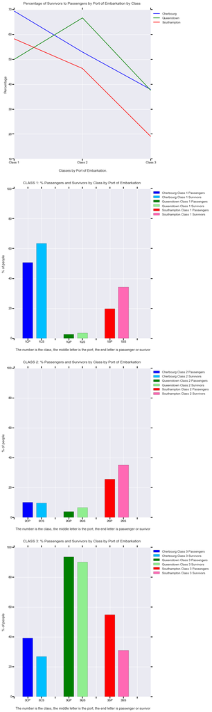

```python
%pylab inline

#allow for multiple figures in the output
#add figsize to increase the height of the y axis
multiple_bars = plt.figure(1, figsize=(8,40))

#FIRST CHART: PERCENTAGE: IS A LINE CHART
#create line chart showing percentage of survivors to passengers within each Class by Port of Embarkation (iloc 4)
def LineChartPercentS2PbyCbyP():
    #graph the line chart as the FIRST chart in the figure
    #with same colors as the bar charts in the previous section, with legend outside the chart on the right
    #for same look and feel to be consistent and look professional
    ay = plt.subplot(411)
    ay.plot ([Pclass_Embarked_summary_total_df.iloc[0,4], Pclass_Embarked_summary_total_df.iloc[3,4], Pclass_Embarked_summary_total_df.iloc[6,4]], color = "b", label="Cherbourg")
    ay.plot ([Pclass_Embarked_summary_total_df.iloc[1,4], Pclass_Embarked_summary_total_df.iloc[4,4], Pclass_Embarked_summary_total_df.iloc[7,4]], color = "g", label="Queenstown")
    ay.plot ([Pclass_Embarked_summary_total_df.iloc[2,4], Pclass_Embarked_summary_total_df.iloc[5,4], Pclass_Embarked_summary_total_df.iloc[8,4]], color = "r", label="Southampton")

    # put ticks to identify the points on the lines for the classes
    xticks( arange(3), ("Class 1", "Class 2", "Class 3") )
    ay.tick_params(direction='out', length=6, width=2, colors='k')
    locs, labels = xticks()

    #add labels - must use .set_ for subplots
    ay.set_xlabel('\n Classes by Port of Embarkation.')
    ay.set_ylabel('Percentage')
    ay.set_title('Percentage of Survivors to Passengers by Port of Embarkation by Class \n')

    # Place a legend to the right of this figure.
    # same style as the graphs in the previous section - for consistency in reporting
    ay.legend(bbox_to_anchor=(1, 1, 1., 0.), loc='upper left')

# SECOND CHART: PERCENTAGE: create a bar chart showing Passengers in Class 1 as a % of total passengers at that port
# and % Survivors in Class 1 as a % of total survivors at that port
# show all 3 ports on the same graph to see if there are any obvious anomalies

def BarChartPctPandSInEachPortClass1():
    #graph the bar chart as the second figure on row 2 of 4 of charts in the figure
    az = plt.subplot(412)

    # For Class 1, iloc[0,x] is Cherbourg [2,x] is Queenston and [3,x] is Southampton

    #Pct passengers by Port for Class1
    #simplify the naming for shorter code for the graphs
    # iloc[,10] is percent of passengers in the class from that port

    y = [Pclass_Embarked_summary_df.iloc[0,10]]
    z = [Pclass_Embarked_summary_df.iloc[1,10]]
    k = [Pclass_Embarked_summary_df.iloc[2,10]]

    #create an x array that will be used to position the bars in the right place on the figure
    x = array( [1])

    #give the bars names for shorter coding; position per the x array, widths of the bars,
    #         color and alignment
    bar1 = az.bar(x, y,width=0.75,color='b',align='center')
    bar3 = az.bar(x+3, z,width=0.75,color='g',align='center')
    bar5 = az.bar(x+6, k,width=0.75,color='r',align='center')

    #survivors
    #simplify the naming for shorter code for the graphs
    # iloc[,12] is percent of survivors

    y = [Pclass_Embarked_summary_df.iloc[0,12]]
    z = [Pclass_Embarked_summary_df.iloc[1,12]]
    k = [Pclass_Embarked_summary_df.iloc[2,12]]

    #create an x array that will be used to position the bars in the right place on the figure
    #to match up the survivor overlay with the passengers by port by class
    x = array( [2])

    #select complimentary colors;
    #give the bars names for shorter coding; position per the x array, widths of the bars,
    #         color; alignment
    #and also so that the legend can be matched up with the right bar chart
    bar2 = az.bar(x, y,width=0.75,color='#00BFFF',align='center')
    bar4 = az.bar(x+3, z,width=0.75,color='#90EE90',align='center')
    bar6 = az.bar(x+6, k,width=0.75,color='#FF69B4',align='center')

    #add maximum height of 100 to shorten the dead space at the top of the chart
    az.axis([0,10,0,100])

    #add ticks and labels so that the numbers can be visually aligned on all sides of the chart
    az.tick_params(direction='out', length=6, width=2, colors='k')
    locs, labels = xticks()

    #give the ticks names on the x axis so that the Class/Port is easily identifiable
    xticks( arange(10), ("", "1CP", "1CS", "", "1QP", "1QS", "", "1SP", "1SS", "") )

    #label the x and Y axes and give the chart a title
    az.set_xlabel('\n The number is the class, the middle letter is the port, the end letter is passenger or suvivor')
    az.set_ylabel('% of people')
    az.set_title('CLASS 1: % Passengers and Survivors by Class by Port of Embarkation \n')

    #add a legend and anchor it on the top right, outside the chart
    az.legend((bar1, bar2, bar3, bar4, bar5, bar6),
              ('Cherbourg Class 1 Passengers', 'Cherbourg Class 1 Survivors', 'Queenstown Class 1 Passengers',
               'Queenstown Class 1 Survivors', 'Southampton Class 1 Passengers', 'Southampton Class 1 Survivors'),
              bbox_to_anchor=(1, 1, 1., 0.), loc='upper left')

# THIRD CHART: PERCENTAGE: create a bar chart showing Passengers in Class 2 as a % of total passengers at that port
# and % Survivors in Class 2 as a % of total survivors at that port
# show all 3 ports on the same graph to see if there are any obvious anomalies

def BarChartPctPandSInEachPortClass2():
    #graph the bar chart as the 3rd figure on row 3 of charts in the figure
    ax = plt.subplot(413)

    # For Class 2, iloc[3,x] is Cherbourg [4,x] is Queenston and [5,x] is Southampton

    #Pct passengers by Port for Class2
    #simplify the naming for shorter code for the graphs
    # iloc[,10] is percent of passengers in the class from that port

    y = [Pclass_Embarked_summary_df.iloc[3,10]]
    z = [Pclass_Embarked_summary_df.iloc[4,10]]
    k = [Pclass_Embarked_summary_df.iloc[5,10]]

    #create an x array that will be used to position the bars in the right place on the figure
    x = array( [1])

    #give the bars names for shorter coding; position per the x array, widths of the bars,
    #         color and alignment
    bar1 = ax.bar(x, y,width=0.75,color='b',align='center')
    bar3 = ax.bar(x+3, z,width=0.75,color='g',align='center')
    bar5 = ax.bar(x+6, k,width=0.75,color='r',align='center')

    #survivors
    #simplify the naming for shorter code for the graphs
    # iloc[,12] is percent of survivors

    y = [Pclass_Embarked_summary_df.iloc[3,12]]
    z = [Pclass_Embarked_summary_df.iloc[4,12]]
    k = [Pclass_Embarked_summary_df.iloc[5,12]]

    #create an x array that will be used to position the bars in the right place on the figure
    #to match up the survivor overlay with the passengers by port by class
    x = array( [2])

    #select complimentary colors;
    #give the bars names for shorter coding; position per the x array, widths of the bars,
    #         color; alignment
    #and also so that the legend can be matched up with the right bar chart
    bar2 = ax.bar(x, y,width=0.75,color='#00BFFF',align='center')
    bar4 = ax.bar(x+3, z,width=0.75,color='#90EE90',align='center')
    bar6 = ax.bar(x+6, k,width=0.75,color='#FF69B4',align='center')

    #add maximum height of 100 to shorten the dead space at the top of the chart
    ax.axis([0,10,0,100])

    #add ticks and labels so that the numbers can be visually aligned on all sides of the chart
    ax.tick_params(direction='out', length=6, width=2, colors='k')
    locs, labels = xticks()

    #give the ticks names on the x axis so that the Class/Port is easily identifiable
    xticks( arange(10), ("", "2CP", "2CS", "", "2QP", "2QS", "", "2SP", "2SS", "") )

    #label the x and Y axes and give the chart a title
    ax.set_xlabel('\n The number is the class, the middle letter is the port, the end letter is passenger or suvivor')
    ax.set_ylabel('% of people')
    ax.set_title('CLASS 2: % Passengers and Survivors by Class by Port of Embarkation \n')

    #add a legend and anchor it on the top right, outside the chart
    ax.legend((bar1, bar2, bar3, bar4, bar5, bar6),
              ('Cherbourg Class 2 Passengers', 'Cherbourg Class 2 Survivors', 'Queenstown Class 2 Passengers',
               'Queenstown Class 2 Survivors', 'Southampton Class 2 Passengers', 'Southampton Class 2 Survivors'),
              bbox_to_anchor=(1, 1, 1., 0.), loc='upper left')


# FOURTH CHART: PERCENTAGE: create a bar chart showing Passengers in Class 3 as a % of total passengers at that port
# and % Survivors in Class 3 as a % of total survivors at that port
# show all 3 ports on the same graph to see if there are any obvious anomalies

def BarChartPctPandSInEachPortClass3():
    #graph the bar chart as the 4th figure on row 4 of charts in the figure
    aw = plt.subplot(414)

    # For Class 3, iloc[6,x] is Cherbourg [7,x] is Queenston and [8,x] is Southampton

    #Pct passengers by Port for Class2
    #simplify the naming for shorter code for the graphs
    # iloc[,10] is percent of passengers in the class from that port

    y = [Pclass_Embarked_summary_df.iloc[6,10]]
    z = [Pclass_Embarked_summary_df.iloc[7,10]]
    k = [Pclass_Embarked_summary_df.iloc[8,10]]

    #create an x array that will be used to position the bars in the right place on the figure
    x = array( [1])

    #give the bars names for shorter coding; position per the x array, widths of the bars,
    #         color and alignment
    bar1 = aw.bar(x, y,width=0.75,color='b',align='center')
    bar3 = aw.bar(x+3, z,width=0.75,color='g',align='center')
    bar5 = aw.bar(x+6, k,width=0.75,color='r',align='center')

    #survivors
    #simplify the naming for shorter code for the graphs
    # iloc[,12] is percent of survivors

    y = [Pclass_Embarked_summary_df.iloc[6,12]]
    z = [Pclass_Embarked_summary_df.iloc[7,12]]
    k = [Pclass_Embarked_summary_df.iloc[8,12]]

    #create an x array that will be used to position the bars in the right place on the figure
    #to match up the survivor overlay with the passengers by port by class
    x = array( [2])

    #select complimentary colors;
    #give the bars names for shorter coding; position per the x array, widths of the bars,
    #         color; alignment
    #and also so that the legend can be matched up with the right bar chart
    bar2 = aw.bar(x, y,width=0.75,color='#00BFFF',align='center')
    bar4 = aw.bar(x+3, z,width=0.75,color='#90EE90',align='center')
    bar6 = aw.bar(x+6, k,width=0.75,color='#FF69B4',align='center')

    #add maximum height of 100 to shorten the dead space at the top of the chart
    aw.axis([0,10,0,100])

    #add ticks and labels so that the numbers can be visually aligned on all sides of the chart
    aw.tick_params(direction='out', length=6, width=2, colors='k')
    locs, labels = xticks()

    #give the ticks names on the x axis so that the Class/Port is easily identifiable
    xticks( arange(10), ("", "3CP", "3CS", "", "3QP", "3QS", "", "3SP", "3SS", "") )

    #label the x and Y axes and give the chart a title
    aw.set_xlabel('\n The number is the class, the middle letter is the port, the end letter is passenger or suvivor')
    aw.set_ylabel('% of people')
    aw.set_title('CLASS 3: % Passengers and Survivors by Class by Port of Embarkation \n')

    #add a legend and anchor it on the top right, outside the chart
    aw.legend((bar1, bar2, bar3, bar4, bar5, bar6),
              ('Cherbourg Class 3 Passengers', 'Cherbourg Class 3 Survivors', 'Queenstown Class 3 Passengers',
               'Queenstown Class 3 Survivors', 'Southampton Class 3 Passengers', 'Southampton Class 3 Survivors'),
              bbox_to_anchor=(1, 1, 1., 0.), loc='upper left')



#run the code for the charts
LineChartPercentS2PbyCbyP()
BarChartPctPandSInEachPortClass1()
BarChartPctPandSInEachPortClass2()
BarChartPctPandSInEachPortClass3()


#show the graphs
plt.show()
```

D. NOTES on the PERCENTAGE CHARTS

D1. FIRST PERCENTAGE CHART: Line graph.

I created the line graph - Percentage of Survivors to Passengers by Port of Embarkation - to show how Queenstown Classes 1 and 2 (referred to as 1Q and 2Q) low quantities' skew the results trending. See how Queenstown is not a straight line from Class 1 to Class 3 percentage survivors, as one would expect from general knowledge: that the Class1 survivors would be > Class2 > Class3.

This was in support of the NOTES on the datafram data in section A which said:

```
      A3. Some of the numbers in Queenstown skew the results:

          The total number of Passengers in Queenstown in 1Q is only 2, and in 2Q is only 3.
          These quantities are very low.
          There is 1 survivor from 1Q and 2 survivors from 2Q.

          These low quantities will skew the percentage of survivors to passengers for 1Q and 2Q.
```

This percentage line chart brings this observation home.

D2. SECOND PERCENTAGE CHART: CLASS 1: % Passengers and Survivors by Class by Port of Embarkation

This chart is in support of the NOTES on the datafram data in section A which said:

```
      A2. Why does Cherbourg have the highest percentage of survivors to passengers (55%)?
          Was there a higher percentage of first class passengers in Cherbourg than there was in other ports?
          This question is investigated below in the percentage section.
```

This PERCENTAGE CHART for CLASS 1 clearly shows that YES, there were more first class passengers from Cherbourg than from Queenston or Southampton. Also, Cherbourg is higher % of Class 1 survival as was seen in the quantities chart, but Southampton has a significantly high Class 1 survival rate as well. Queenston quantities are too low to be significant as already pointed out in A3 and D1.

D3. THIRD PERCENTAGE CHART: CLASS 2: % Passengers and Survivors by Class by Port of Embarkation

Southampton has a significantly higher % of survivors in class 2 compared to it's % of passengers in class 2. The reasons for this are not brought out from within the scope of this project.

as pointed out in A4 and in A5, other factors may be at work: A4. Investigation that led nowhere: Were the Southhampton cabins from certain ports in a less desirable part of the ship? I had hoped that the ticket_no would be an indication of an answer to this question, but even though I cleaned the ticket_no data, it was not clear what the ticket numbers meant. I searched online to see if any research had been done in the archives on what the ticket numbers or prefix meant, but I was unable to find any answers. This was disappointing.

```
      A5. Other factors outside of the scope of this project:
          This project is centered on Passengers and Survivors by Class by Port.
          But a comprehensive conclusion would also consider the number of females, children, elderly and
          so on between the ports. These factors are outside of the scope of this project,
          but the data exists to analyse it in another project.
```

So, that analysis could be done in another project.

D4. FOURTH PERCENTAGE CHART: CLASS 3: % Passengers and Survivors by Class by Port of Embarkation

This chart shows what is to be expected, that there are fewer 3rd Class survivors than there were 3rd Class Passengers at each port. It is interesting to note that the makeup of passengers and survivors at Queenston was mostly 3rd Class. Perhaps Queenston is more of a working class town. But that is just a thought which cannot be verified based on the data. A sociological study of the 3 ports would need to be undertaken to draw that conclusion.

#### Code for saving the final data files to my path for submission with my project

```python
# Write DataFrame to CSV to store for project submission
#index = False so that the row nos - index - are not saved

#I have 3 files that I want to save.
# 1. the final, cleaned data that I used: final_ticket_df.to_csv('c:/DA/CSV files/final_ticket_titanic_df.csv', index=False)
# 2. the summary data by port: Embarked_summary_total_df.to_csv(path + 'Embarked_summary_total_df.csv', index=False)
# 3. the summary data by class by port: Pclass_Embarked_summary_total_df.to_csv(path + 'Pclass_Embarked_summary_total_df.csv', index=False)

final_ticket_df.to_csv(path + 'final_ticket_titanic_df.csv', index=False)
Embarked_summary_total_df.to_csv(path + 'Embarked_summary_total_df.csv', index=False)
Pclass_Embarked_summary_total_df.to_csv(path + 'Pclass_Embarked_summary_total_df.csv', index=False)

#I checked that the files were written to the path - and they are
#read it in to double check
#keep_default_na=False if I do not want the empty cells to be filled with NaN
#default is that they will be filled with NaN

#set to True to read file back in as a new name and confirm by printing that the fields are the same
#This argument is not required because I dont have any na in the file: na_values=[""]
#But if I wanted to convert na to "" then that is what I would use
#This argument is required so that the empty cells are not converted to NaN: keep_default_na=False

#set to True to see some sample rows of the files from the code above before saving:
#then read the files in, print the files and check that the file is saved and that it is same
if True:
    print ""
    print "DATA FILES BEFORE AND AFTER SAVING"
    print ""
    print ""
    print "Print 1st File of cleaned data from code above before saving: final_ticket_df - print only the first few rows"
    print final_ticket_df.head()
    print ""
    print ""
    print "Check that the 1st file of cleaned data was saved, then opened as FirstDataCheckFileSaved and looks the same - print only the first few rows"
    FirstDataCheckFileSaved = pd.read_csv(path + 'final_ticket_titanic_df.csv', keep_default_na=False)
    print FirstDataCheckFileSaved.head()
    print ""
    print ""
    print ""
    print ""
    print "Print 2nd File of summary data by port of Embarkation from code above before saving: Embarked_summary_total_df - print all 3 rows"
    print Embarked_summary_total_df
    print ""
    print ""
    print "Check that the 2nd file of port of Embarkation summary was saved, then opened as SecondDataCheckFileSaved and looks the same - print all 3 rows"
    SecondDataCheckFileSaved = pd.read_csv(path + 'Embarked_summary_total_df.csv', keep_default_na=False)
    print SecondDataCheckFileSaved
    print ""
    print ""
    print ""
    print ""
    print "Print 3rd File of summary data by Class by port of Embarkation from code above before saving: Pclass_Embarked_summary_total_df - print all 9 rows"
    print Pclass_Embarked_summary_total_df
    print ""
    print ""
    print "Check that the 3rd file of Class by port of Embarkation summary was saved, then opened as ThirdDataCheckFileSaved and looks the same - print all 9 rows"
    ThirdDataCheckFileSaved = pd.read_csv(path + 'Pclass_Embarked_summary_total_df.csv', keep_default_na=False)
    print ThirdDataCheckFileSaved
    print ""
    print ""
    print ""
    print ""
    print "They look the same. Success."
```

```
DATA FILES BEFORE AND AFTER SAVING


Print 1st File of cleaned data from code above before saving: final_ticket_df - print only the first few rows
  Ticket_Prefix Ticket_No  Survived  Pclass Embarked  Latitude  Longitude
0            A5     21171         0       3        S   50.9000     1.4000
1            PC     17599         1       1        C   48.5335     7.7829
2       SOTONO2   3101282         1       3        S   50.9000     1.4000
3                  113803         1       1        S   50.9000     1.4000
4                  373450         0       3        S   50.9000     1.4000


Check that the 1st file of cleaned data was saved, then opened as FirstDataCheckFileSaved and looks the same - print only the first few rows
  Ticket_Prefix Ticket_No  Survived  Pclass Embarked  Latitude  Longitude
0            A5     21171         0       3        S   50.9000     1.4000
1            PC     17599         1       1        C   48.5335     7.7829
2       SOTONO2   3101282         1       3        S   50.9000     1.4000
3                  113803         1       1        S   50.9000     1.4000
4                  373450         0       3        S   50.9000     1.4000




Print 2nd File of summary data by port of Embarkation from code above before saving: Embarked_summary_total_df - print all 3 rows
  Embarked  Passengers  Survived      %StoP  TotalPassengers  TotalSurvived  \
0        C         168        93  55.357143              889            340
1        Q          77        30  38.961039              889            340
2        S         644       217  33.695652              889            340

   %PToTotalPassengers  %SToTotalSurvived
0            18.897638          27.352941
1             8.661417           8.823529
2            72.440945          63.823529


Check that the 2nd file of port of Embarkation summary was saved, then opened as SecondDataCheckFileSaved and looks the same - print all 3 rows
  Embarked  Passengers  Survived      %StoP  TotalPassengers  TotalSurvived  \
0        C         168        93  55.357143              889            340
1        Q          77        30  38.961039              889            340
2        S         644       217  33.695652              889            340
```

[output cut: 67 more lines]

```
   %PToPInPort  SInPort  %SToSInPort
0    50.595238       93    63.440860
1     2.597403       30     3.333333
2    19.720497      217    34.101382
3    10.119048       93     9.677419
4     3.896104       30     6.666667
5    25.465839      217    35.023041
6    39.285714       93    26.881720
7    93.506494       30    90.000000
8    54.813665      217    30.875576




They look the same. Success.
```

## Step Four - Share your findings

I have used IPython notebooks for my report since it allows me to display nicely formatted results, such as plots, directly in the notebook. I used NumPy, Pandas and Matplotlib in my code and plots.

I have shared findings that I found most interesting, alongside the code that I used to perform the analysis.

See above

A. NOTES on the initial DATABASE NUMBERS,

B. NOTES on the SCATTER / BUBBLE charts

DATABASE display of Embarked and Pclass_Embarked with quantities only

C. NOTES on the QUANTITIES charts

DATABASE display of Embarked_Summary_Total_df and Pclass_Embarked_Summary_Total_df with percentage fields added

D. NOTES on the PERCENTAGE charts

DATA FILES BEFORE AND AFTER SAVING

E. SUMMARY NOTES:

E1. Process

```
•    I was particularly interested in looking at the Titanic data based on the ticket_no. I cleaned the ticket_no data.

•    LIMITATION: I wanted to see how many missing tickets there were by class. Unfortunately I discovered that the titanic data did not provide this information. It only provides information on the passengers that boarded the ship, not the people that bought tickets that did not board the ship.


•    AVOID A BIAS: So, I moved to my next question of interest “is there a relationship between the Port of Embarkation and the Class?” This question provided sufficient information to complete the rest of the project, so I did not have to move down my list of questions any further.

•    I refined the fields in the database to focus on the passengers and survivors to answer my lead question: Passengers in which Classes and points of Embarkation were more likely to survive?

•    POTENTIAL BIAS: I was hoping to see if the actual Port of Embarkation provided any clues as to the sociological makeup of the people that boarded the ship. I also wanted to see where the ports were in relation to each other, so I plotted the ports by latitude and longitude. This allowed me to output scatter / bubble charts.

    o    I started with THE NUMBER OF passenger bubble by port
    •    THE COLORS ON ALL 3 BUBBLE GRAPHS ARE RANDOM AND DON’T MEAN ANYTHING - I ADDED A COMMENT TO THAT EFFECT IN THE XAXIS LABEL OF ALL 3 BUBBLE PLOTS. THE SIZE OF THE CIRCLES SHOW THE RELATIVE NUMBER OF PASSENGERS OR SURVIVORS BETWEEN THE PORTS. I ADDED A COMMENT TO THAT EFFECT IN THE TITLE OF ALL 3 BUBBLE PLOTS.

    o    Then I did a bubble chart of the NUMBER OF survivors by port

    o    Then I combined the 2 charts into a 3rd overlay chart of the survivor circle within the passenger circle.


•    I made comments on the cleaned data under “A. Notes”.


•    I wrote my findings on the Bubble charts under “B. Notes”.


•    I displayed the databases of so that the actual numbers could be reviewed.


•    The number of passengers and survivors by Port and by Class/by Port was interesting, and I built bar charts accordingly.


•    There were 2 bar charts on the quantities of passengers and survivors

    o    By Port

    o    By Class / by Port


•    I documented my findings related to these bar charts in “C. Notes”.


•    LIMITATION: The actual quantity of passengers and survivors at each port was not sufficient for me to draw conclusions of the differences between the ports, so I added fields to the dataframes to include percentages for easier identification of the fine differences between the Classes, Ports, Passengers and Survivors.

    o    % of survivors to passengers by port.

    o    % of passengers at the port to total passengers on the ship.

    o    % of survivors at the port to total survivors from the ship.

    o    % of passengers by class to the total passengers from that port, for each port.

    o    % of survivors by class to the total survivors from that port, for each port.


•    I created a line graph – Percentage of Survivors to Passengers by Port – to show how Queenstown Classes 1 and 2 low quantities skew the results trending – WHICH WOULD HAVE BEEN A BIAS. The line for Queenstown was not a gradual decrease from Class 1 survivor % down to Class 3 survivor percent. It bounced way up for Class 2. This showed that the low quantities of passengers and survivors in class 2 skewed the results and cannot be relied on to draw conclusions.


•    I also created 3 bar graphs, one for each class, to show % passengers and survivors by class by port. These 3 bar have a different layout than the previous bar graphs. Rather than showing the survivors as an overlay, the survivors bar is beside the passenger bar by class. I created the graphs to show Class 1 passengers and survivors first for all 3 ports, then Class 2 for all 3 ports, then Class 3. This allowed me to meet my objective of clearly showing the differences between the ports for each class.


•    I wrote “D. Notes” to describe the findings in the percentage graphs.


•    After saving my new dataframes as csv files, I opened them and displayed the dataframes before saving  and after saving so that it was clear that the files were saved properly.
```

E2. Summary of my Findings:

[output not shown]

## Step 5 - Review

I have checked my report against the Project Rubric https://docs.google.com/document/d/1YzdSG-rYJuNSprUppkpeno_lobQ7izUxYj_sCUrY3Rg/pub?embedded=true and reviewed my project. I found room for improvement and revised my project. I am happy with my submission.

Meet expectations:

```
•    It has been a pleasure working on this project.

    o    All code is functional and produces no errors when run. The code given is sufficient to reproduce the results described.

    o     The project uses NumPy arrays and Pandas Series and DataFrames where appropriate rather than Python lists and dictionaries. Where possible, vectorized operations and built-in functions are used instead of loops.

    o    The code makes use of functions to avoid repetitive code. The code contains good comments and variable names, making it easy to read.

    o    The project clearly states one or more questions, then addresses those questions in the rest of the analysis.

    o    The project documents any changes that were made to clean the data, such as merging multiple files, handling missing values, etc.

    o    The project investigates the stated question(s) from multiple angles. At least three variables are investigated using both single-variable (1d) and multiple-variable (2d) explorations.

    o    The project's visualizations are varied and show multiple comparisons and trends. Relevant statistics are computed throughout the analysis when an inference is made about the data. This project makes use of percentages.

    o    Three kinds of plots are as part of the explorations. (scatter/bubble, line and bar)

    o    The results of the analysis are presented such that any limitations are clear. The analysis does not state or imply that one change causes another based solely on a correlation.

    o    Reasoning is provided for each analysis decision, plot, and statistical summary.

    o    Visualizations made in the project depict the data in an appropriate manner that allows plots to be readily interpreted. The project makes use of consistent colors between the plots, and uses title, legends, tics and labels to assist the reader.

    o    The project uses Markdown cells to report the findings.

    o    Many many references were used in preparing this project. They are listed in the last markdown section.
```

# References - A list of Web sites, books, forums, blog posts, github repositories

## References - links used in the Data Analysis Course

### Links for Intro to Data Analysis Course - prerequisite to P2:Investigate a Dataset

1. Python Notebook: https://ipython.org/notebook.html
2. Python Notebook full documentation: http://ipython.org/ipython-doc/stable/notebook/index.html
3. Python change directory: http://stackoverflow.com/questions/431684/how-do-i-cd-in-python
4. This page explains the difference between iterators and lists in Python, and how to use iterators: https://www.codementor.io/python/tutorial/python-generators-and-iterators
5. Count how many lines are in a csv python: http://stackoverflow.com/questions/16108526/count-how-many-lines-are-in-a-csv-python
6. Python count the number of unique elements in csv column: http://stackoverflow.com/questions/29634417/python-count-number-of-unique-elements-in-csv-column
7. Delete an element from a dictionary: http://stackoverflow.com/questions/5844672/delete-an-element-from-a-dictionary
8. Python Break Statement: http://www.tutorialspoint.com/python/python_break_statement.htm
9. Does Python evaluate if conditions lazily: http://stackoverflow.com/questions/13960657/does-python-evaluate-ifs-conditions-lazily
10. Numpy and Pandas Cheatsheet: https://storage.googleapis.com/supplemental_media/udacityu/5435548805/numpy_pandas_cheatsheet.pdf
11. Getting ipython notebook output: http://stackoverflow.com/questions/13036197/ipython-notebook-getting-output
12. documentation for the argmax() function in Pandas: http://pandas.pydata.org/pandas-docs/stable/generated/pandas.Series.argmax.html
13. documentation for Python's split() function: Good documentation for cleaning up data: https://docs.python.org/2/library/stdtypes.html#str.split
14. Values of Pearson correlation: http://onlinestatbook.com/2/describing_bivariate_data/pearson.html
15. Interpreting correlations: http://rpsychologist.com/d3/correlation/
16. Bessel’s correction: https://en.wikipedia.org/wiki/Bessel%27s_correction
17. Shift function: http://pandas.pydata.org/pandas-docs/stable/generated/pandas.DataFrame.shift.html
18. Replace NaN with zero in Pandas: http://stackoverflow.com/questions/13295735/how-can-i-replace-all-the-nan-values-with-zeros-in-a-column-of-a-pandas-datafra
19. A helper function: http://stackoverflow.com/questions/15128424/recursion-and-helper-function
20. Decimals in python: http://stackoverflow.com/questions/455612/limiting-floats-to-two-decimal-points
21. Get a list of my column names: http://stackoverflow.com/questions/19482970/get-list-from-pandas-dataframe-column-headers
22. See plots in ipython notebook: %pylab inline http://stackoverflow.com/questions/19410042/how-to-make-ipython-notebook-matplotlib-plot-inline
23. Pandas sort: http://pandas.pydata.org/pandas-docs/stable/generated/pandas.DataFrame.sort.html
24. Matplot documentation: http://matplotlib.org/api/pyplot_api.html
25. Kaggle list of field descriptions: https://www.kaggle.com/c/titanic/data

### Here are the links of research that I did on ticket number

1. Looking for Ticket data – this did not help: http://optional.is/required/2012/04/25/titanic-visualized/
2. Looking for Ticket data – this link takes into consideration ticket count by ticket number. This is interesting. Has Kaggle score of .7999 – but I still don’t know what the ticket #s mean – how to break down the ticket # - e.g. numbers starting with 3… are they suppose to be third class? What about the ticket numbers starting with character? Are they workers? Apparently the band played for 2 hours and went down with the ship, what is their ticket number?: http://rstudio-pubs-static.s3.amazonaws.com/24969_894d890964fd4308ab537bfde1f784d2.html
3. Looking for Ticket data – do the ticket numbers mean anything – this had good suggestion to parse the prefix and analyse by class / gender, etc… but not all I wanted: https://www.kaggle.com/c/titanic/forums/t/11127/do-ticket-numbers-mean-anything
4. Indexing and slicing: http://www.datacarpentry.org/python-ecology/02-index-slice-subset
5. Looking for Ticket data – feature scaling ticket fare – asked a question, but no answer: https://www.kaggle.com/c/titanic/forums/t/2852/feature-scaling-ticket-fare
6. Looking for Ticket data – do individuals within the same family have the same ticket numer: https://www.kaggle.com/c/titanic/forums/t/9572/do-individuals-with-the-same-ticket-number-come-from-the-same-family

   > a. Question on this link: I know that people from the same family have the same ticket number. But is the converse true: people with the same ticket number come from the same family? b. Answer: I don't see strong evidence for this one, take ticket number 13502. There are 3 people on that ticket number, none of whom share last names and one of whom has a SibSp + Parch = 0. These clusters might still be very useful though, because they're still traveling in a group. SibSp seems to have a general negative correlation for survival, but I'd also guess that being a man that's part of a ticket group with women is going to be massively helpful.</cite>
7. Looking for Ticket data – fare meaning – not everyone with same ticket paid same fare, so not sure how fare is used: https://www.kaggle.com/c/titanic/forums/t/3916/fare-meaning
8. Looking for Ticket data – Titanic facts, including ticket price: http://www.keyflux.com/titanic/facts.htm
9. Looking for Ticket data – this link is ticket prices for a Titanic exhibition – not relevant: http://premier.ticketek.com.au/shows/show.aspx?sh=TITANIC16&utm_source=ticketek.com.au&utm_medium=friendlylink&utm_campaign=TITANIC16
10. Looking for Ticket data – nothing to do with ticket prices on the Titanic. Only the Ford Museum: https://www.thehenryford.org/explore/inside/past-exhibits/
11. Looking for Ticket data: https://en.wikipedia.org/wiki/Passengers_of_the_RMS_Titanic

    > a. The Titanic's passengers were divided into three separate classes, determined not only by the price of their ticket but by wealth and social class: those travelling in first class, the wealthiest passengers on board, were prominent members of the upper class and included businessmen, politicians, high-ranking military personnel, industrialists, bankers and professional athletes. Second class passengers were middle class travellers and included professors, authors, clergymen and tourists. Third class or steerage passengers were primarily immigrants moving to the United States and Canada b. Ticket holders who did not sail: Numerous notable and prominent people of the era, who held tickets for the westbound passage or were guests of those who held tickets, did not sail. Among those who held tickets for a passage, but did not actually sail include John Pierpont Morgan, Henry Clay Frick, Milton S. Hershey, Theodore Dreiser, Guglielmo Marconi, Edgar Selwyn, Alfred Gwynne Vanderbilt, and Hugh Sullivan.[27 c. Regarding where the passengers were situated in bow versus stern. For 3rd class passengers the above link says: Rather than dormitory-style sleeping areas, third class passengers had their own cabins. The single men and women were separated, women in the stern in two to six berth cabins, men in the bow in up to ten berth cabins, often shared with strangers… the bow cabins which did not have a private washbasin. d. Ship's regulations were designed to keep third class passengers confined to their area of the ship. The Titanic was fitted with grilles to prevent the classes from mingling and these gates were normally kept closed, although the stewards could open them in the event of an emergency. In the rush following the collision, the stewards, occupied with waking up sleeping passengers and leading groups of women and children to the boat deck, did not have time to open all the gates e. Captain Smith finally ordered the lifeboats to be loaded and lowered under the orders women and children first. </cite>
12. Looking for Ticket data – how much did a ticket cost: http://www.rarityguide.com/forums/history-military-society-culture/3751-how-much-did-ticket-titanic-cost-1912-1st-class-2nd-class-3rd-etc.html

    > a. Answer: b. Costs of Tickets were:

> First Class (parlor suite) £870/$4,350 $50,000 today)

> First Class (berth) £30/$150 $1724 today)

> Second Class £12/$60 ($690 today)

> Third Class £3 to £8/$40 $172 to $460 today </cite>
> 1. Looking for Ticket data – cost of third class ticket: https://alookthrutime.wordpress.com/tag/cost-of-third-class-titanic-ticket/ a. A third class ticket ranged from seven to forty pounds, which would be approximately $700 today. Children’s tickets were three pounds {about $300 today}. Depending on their port of departure, some tickets also included the price for rail travel. </cite>

### More links for coding

1. Indexing, Slicing and Subsetting DataFrames in Python: http://www.datacarpentry.org/python-ecology/02-index-slice-subset
2. Change color in markdown cell: http://stackoverflow.com/questions/19746350/how-does-one-change-color-in-markdown-cells-ipython-notebook
3. How to change font in markdown cell: http://stackoverflow.com/questions/22386359/how-to-change-font-in-ipython-notebook
4. Markdown cheatsheet: http://nestacms.com/docs/creating-content/markdown-cheat-sheet
5. Change font size Stack Overflow: http://stackoverflow.com/questions/34303422/how-to-change-the-font-size-and-color-of-markdown-cell-in-ipython-py-2-7-noteb
6. Underline in ipython notebook markdown - this did not have the answer: http://www.google.ca/url?sa=t&rct=j&q=&esrc=s&source=web&cd=2&ved=0ahUKEwiklsu-larLAhUGMyYKHdBoBqwQFggiMAE&url=http%3A%2F%2Fwww.complexity.co.kr%2F%3Fp%3D1441&usg=AFQjCNFtD9THT6HlrIQpv2WCIbF55qBY0A&bvm=bv.116274245,d.eWE
7. Undeline in ipython notebook markdown: http://stackoverflow.com/questions/23271575/printing-bold-colored-etc-text-in-ipython-qtconsole
8. Shortcut for run all cells - complex - no quick way: https://github.com/ipython/ipython/issues/2228
9. Data Carpentry lessons on Python... was good for indexing slicing above... use for other things as well: http://www.datacarpentry.org/python-ecology/
10. Splitting a column in two: http://stackoverflow.com/questions/14745022/pandas-dataframe-how-do-i-split-a-column-into-two 47.Splitting a column in two: http://queforum.com/python/572236-python-pandas-dataframe-how-do-i-split-column-into-two.html
11. Assign column names: http://stackoverflow.com/questions/11346283/renaming-columns-in-pandas
12. Concatenate 2 cols of text in python: http://stackoverflow.com/questions/19377969/combine-two-columns-of-text-in-dataframe-in-pandas-python
13. Fixing concatenation error: http://stackoverflow.com/questions/34670374/concat-two-columns-with-pandas
14. Replace NaN with None: http://stackoverflow.com/questions/14162723/replacing-pandas-or-numpy-nan-with-a-none-to-use-with-mysqldb
15. Replace NaN with Blank Empty string: http://stackoverflow.com/questions/26837998/pandas-replace-nan-with-blank-empty-string
16. Merge dataframes: http://www.datacarpentry.org/python-ecology/04-merging-data
17. Reading / Writing files in python: https://docs.python.org/2/library/csv.html
18. Do not save the index no: http://stackoverflow.com/questions/20845213/how-to-avoid-python-pandas-creating-an-index-in-a-saved-csv
19. keep_default_na=False - this means that na will not be converted to NaN: http://stackoverflow.com/questions/26659941/pandas-read-csv-named-argument-na-values-default-values
20. How to use groupby: http://stackoverflow.com/questions/773/how-do-i-use-pythons-itertools-groupby
21. how do I mark multiple lines as comment - you cant: http://stackoverflow.com/questions/7696924/multiline-comments-in-python
22. how do I sort dataframe:
23. Converting pandas groupby object to dataframe: http://stackoverflow.com/questions/10373660/converting-a-pandas-groupby-object-to-dataframe
24. Strip characters from cells: http://stackoverflow.com/questions/13682044/pandas-dataframe-remove-unwanted-parts-from-strings-in-a-column
25. Strip again: http://stackoverflow.com/questions/14345739/replacing-part-of-string-in-python-pandas-dataframe
26. and Strip again: http://stackoverflow.com/questions/23839465/python-pandas-replace-special-character
27. Replace instead of strip - strip only removes at the start and end of the string: http://stackoverflow.com/questions/14345739/replacing-part-of-string-in-python-pandas-dataframe
28. Make all characters upper or lower: http://stackoverflow.com/questions/1801668/convert-a-python-list-with-strings-all-to-lowercase-or-uppercase
29. Give an index a name: http://stackoverflow.com/questions/18022845/pandas-index-column-title-or-name
30. Find latitude and longitude of Cherbourg France: http://www.distancesfrom.com/Cherbourg-port-France-latitude-longitude-Cherbourg-port-France-latitude-Cherbourg-port-France-longit/LatLongHistory/880115.aspx
31. Find latitude and longitude of Queenstown, UK and Southhampton, UK: http://www.worldatlas.com/aatlas/findlatlong.htm
32. Convert latitude and longitude to decimals: https://www.google.ca/search?q=convert+latitude+and+longitude+to+decimal+degrees&ie=utf-8&oe=utf-8&gws_rd=cr&ei=4fTlVoDoIMnsjwOgup8Q
33. Add a column to a dataframe: http://stackoverflow.com/questions/12555323/adding-new-column-to-existing-dataframe-in-python-pandas
34. Evaluating pandas series values with if statements and logical expressions: http://stackoverflow.com/questions/23461502/evaluating-pandas-series-values-with-logical-expressions-and-if-statements
35. Pandas change one value based on another value: http://stackoverflow.com/questions/19226488/python-pandas-change-one-value-based-on-another-value
36. Make bubbles larger in bubble plot: http://stackoverflow.com/questions/14827650/pyplot-scatter-plot-marker-size
37. Annotations on plots: http://stackoverflow.com/questions/10284847/python-matplotlib-annotate-line-break-with-and-without-latex
38. Multiple lines in a label: http://stackoverflow.com/questions/2660319/putting-newline-in-matplotlib-label-with-tex-in-python
39. What does lamda mean: http://stackoverflow.com/questions/1583617/what-does-lambda-mean-in-python-and-whats-the-simplest-way-to-use-it/1583627
40. What’s a hash tree: http://stackoverflow.com/questions/14641479/good-merkle-hash-tree-python-implementation
41. Definition of hash table: https://en.wikipedia.org/wiki/Hash_table
42. Definition of hash tree: https://en.wikipedia.org/wiki/Hash_tree ; https://en.wikipedia.org/wiki/Hash_tree_%28persistent_data_structure%29 ; https://en.wikipedia.org/wiki/Tree_%28data_structure%29
43. How to print 2 columns – it helped me to figure out my problem, but it was not a specific answer to the question: https://video.search.yahoo.com/video/play;_ylt=A2KLqINWu1RXbCUAFdssnIlQ;_ylu=X3oDMTByN2RnbHFoBHNlYwNzcgRzbGsDdmlkBHZ0aWQDBGdwb3MDMw--?p=How+Do+I+Print+Selected+Columns+In+Python&vid=5c690945d31114738d722e1bd3b911ee&turl=https%3A%2F%2Ftse4.mm.bing.net%2Fth%3Fid%3DOVP.Vbb8defcd08cb61120efa737cc1b45b36%26pid%3D15.1%26h%3D168%26w%3D300%26c%3D7%26rs%3D1&rurl=https%3A%2F%2Fwww.youtube.com%2Fwatch%3Fv%3DjQ9aDyBWCXI&tit=Manipulating+data+using+the+csv+module+in+Python&c=2&h=168&w=300&l=298&sigr=11bqd5clk&sigt=11gmelrq2&sigi=132egtkfj&age=1354030893&fr2=p%3As%2Cv%3Av&fr=yhs-mozilla-004&hsimp=yhs-004&hspart=mozilla&tt=b
44. How to sort multiple columns – very good description: https://wiki.python.org/moin/HowTo/Sorting
45. Bar chart syntax: https://plot.ly/matplotlib/bar-charts/
46. Line chart syntax: http://matplotlib.org/users/pyplot_tutorial.html
47. Bar charts with multiple keys: http://stackoverflow.com/questions/14270391/python-matplotlib-multiple-bars https://plot.ly/matplotlib/bar-charts/
48. Definition of subplot(111): http://stackoverflow.com/questions/3584805/in-matplotlib-what-does-the-argument-mean-in-fig-add-subplot111
49. Format of subplots: http://matplotlib.org/api/pyplot_api.html#matplotlib.pyplot.subplot
50. Indexing: http://pandas.pydata.org/pandas-docs/stable/indexing.html
51. How to save a list as numpy array: http://stackoverflow.com/questions/5951135/how-to-save-a-list-as-numpy-array-in-python
52. What color choices do I have in matplot: http://matplotlib.org/api/colors_api.html
53. The hex color table: http://www.w3schools.com/colors/colors_names.asp
54. How do I make Matplotlib graph more spaced out?: http://stackoverflow.com/questions/19479659/how-do-i-make-matplotlib-graph-more-spaced-out
55. Change start of plot on x axis and other tips: http://matplotlib.org/1.4.0/users/pyplot_tutorial.html
56. How do I add an xlabel on a subplot? http://stackoverflow.com/questions/6963035/pyplot-axes-labels-for-subplots
57. How do I add a legend on the right of a plot? http://matplotlib.org/users/legend_guide.html
58. Legend outside the plot: http://stackoverflow.com/questions/30413789/matplotlib-automatic-legend-outside-plot
59. Matplot legend guide: http://matplotlib.org/users/legend_guide.html#plotting-guide-legend
60. Matplot legend: http://matplotlib.org/api/pyplot_api.html#matplotlib.pyplot.legend This link has the codes for where the location of the label is.
61. Convert list to numbers: http://www.dotnetperls.com/convert-python
62. Square brackets in python: http://stackoverflow.com/questions/8900166/whats-the-difference-between-lists-enclosed-by-square-brackets-and-parentheses • Square brackets are lists while parentheses are tuples.
63. How to determine the variable type in Python: http://stackoverflow.com/questions/402504/how-to-determine-the-variable-type-in-python
64. convert list element to number: http://stackoverflow.com/questions/3371269/call-int-function-on-every-list-element-in-python
65. use a list in numerical operation: http://stackoverflow.com/questions/6645357/doing-math-to-a-list-in-python
66. Convert Int to Float: https://www.google.com/?gws_rd=ssl#q=python+convert+int+to+float
67. What is a long integer: https://www.google.com/?gws_rd=ssl#q=python+what+is+a+long+integer
68. Using columns in calculations: http://stackoverflow.com/questions/12376863/adding-calculated-columns-to-a-dataframe-in-pandas
69. Defining functions on your own: http://anh.cs.luc.edu/python/hands-on/3.1/handsonHtml/functions.html
70. Definition of dependent and independent variables: https://books.google.ca/books?id=eR-vCgAAQBAJ&pg=PA9&lpg=PA9&dq=python+dependent+and+independent+variables&source=bl&ots=0SJi-vHSof&sig=60oa5ZZ2RFbZWD1t48dWHiF_8k4&hl=en&sa=X&ved=0ahUKEwjo8Nv19ozOAhUi5IMKHagQDnMQ6AEITTAI#v=onepage&q=python%20dependent%20and%20independent%20variables&f=false
71. Convert input to raw_input: http://stackoverflow.com/questions/16155552/equivalent-of-raw-input-in-ipython-notebook
72. Print function print() with set=’’: http://stackoverflow.com/questions/22116482/python-syntax-help-sep-t
73. Keep Python print from adding new lines or spaces: http://stackoverflow.com/questions/255147/how-do-i-keep-python-print-from-adding-newlines-or-spaces
74. Python course from luc.edu: http://anh.cs.luc.edu/python/hands-on/3.1/handsonHtml/index.html
75. Loop until end of file: http://stackoverflow.com/questions/29022377/how-to-while-loop-until-the-end-of-a-file-in-python-without-checking-for-empty-l